# Task 2: Agglomerative hierarchical clustering

Claire Meuter

2023-03-05

```r
knitr::opts_chunk$set(echo = TRUE, warning = FALSE, message = FALSE)
library(tidyverse) #all hail the tidyverse
library(dendextend) #tanglegram
library(ggdendro)
library(here) #easy reading
```

## Introduction

**Reference:** Santa Barbara Coastal LTER and J. Melack. 2019. SBC LTER: Land: Stream chemistry in the Santa Barbara Coastal drainage area, ongoing since 2000 ver 16. Environmental Data Initiative. https://doi.org/10.6073/pasta/67a558a24ceed9a0a5bf5e46ab841174.

## Data wrangling

Here, I’ll read in the raw data and prepare it for a hierarchical clustering. I’m going to drop any variables with a high (>50%) occurrence of NAs. I convert any -999 values to NA. I will rename site locations. I’ll evaluate for and delete any variables that have more than a 50% NAs. I will find the average stream chemistry values for each site, and the scale the data to easily calculate euclidean distances.

```r
#read in the data
stream <-
  read_csv(here("data","sbc_lter_registered_stream_chemistry.csv")) %>%
  na_if(-999) %>%  #assigning na to -999 values
  mutate(site_name = case_when(site_code == 'AB00' ~ 'Arroyo Burro',
                               site_code == 'AT07' ~ 'Atascadero Creek',
                               site_code == 'BC02' ~ 'Bell Canyon Creek',
                               site_code == 'DV01' ~ 'Devereaux Creek',
                               site_code == 'GV01' ~ 'Gaviota',
                               site_code == 'HO00' ~ 'Arroyo Hondo',
                               site_code == 'MC00' ~ 'Mission Creek (Montecito St)',
                               site_code == 'MC06' ~ 'Mission Creek (Rocky Nook)',
                               site_code == 'ON02' ~ 'San Onofre Creek',
                               site_code == 'RG01' ~ 'Refugio Creek',
                               site_code == 'RS02' ~ 'Rattlesnake Creek',
                               site_code == 'SP02' ~ 'San Pedro Creek',
                               site_code == 'TO02' ~ 'Tecolote Creek'),
         .after = site_code) #renaming the sites



### explore the number of NAs by variable
 #colSums(is.na(stream))
 #  site_code         site_name   timestamp_local            nh4_uM
    #            0                 0                 0               203
  #         no3_uM            po4_uM            tdn_uM            tdp_uM
   #           149               167              5034              5801
   #        tpc_uM            tpn_uM            tpp_uM    tss_mgperLiter
   #         16521             16521             17046             14376
#spec_cond_uSpercm
  #            924

#There are 19,390 obs, so I want to drop any variables that have more than 9,695 NAs.
# - tpc-uM, tpn_uM, tpp_uM, tss_mgperLiter all have more than 50% NAs

### I'll drop them from the analysis
### Next, I find the average values by stream site.


stream_avgs <- stream %>%
  select(!c(tpc_uM, tpn_uM, tpp_uM, tss_mgperLiter)) %>% #dropping unwanted variables
  drop_na() %>%
  group_by(site_name) %>%
  summarize(nh4_mean = mean(nh4_uM, na.rm = TRUE),
            no3_mean = mean(no3_uM, na.rm = TRUE),
            po4_mean = mean(po4_uM, na.rm = TRUE),
            tdn_mean = mean(tdn_uM, na.rm = TRUE),
            tdp_mean = mean(tdp_uM, na.rm = TRUE),
            spec_cond_mean = mean(spec_cond_uSpercm, na.rm = TRUE))
### Next I scale the numeric data
stream_chem_scale <- stream_avgs %>%
  select(where(is.numeric)) %>%
  scale()
### reassign rownames based on site name
rownames(stream_chem_scale) <- stream_avgs$site_name
```

## Hierarchical clustering

Hierarachical clustering can be top-down, or bottom-up. As stated above, am agglomerate method means that we take a bottom-up approach. In other words, our stream sites are each treated as their own cluster, and we now need to group them together based on similarity. To do this, I need to calculate the Euclidean distance in multivariate space between the different observations. This matrix of distances will allow me perform hierarchical clustering. These results can be displayed by a dendrogram.

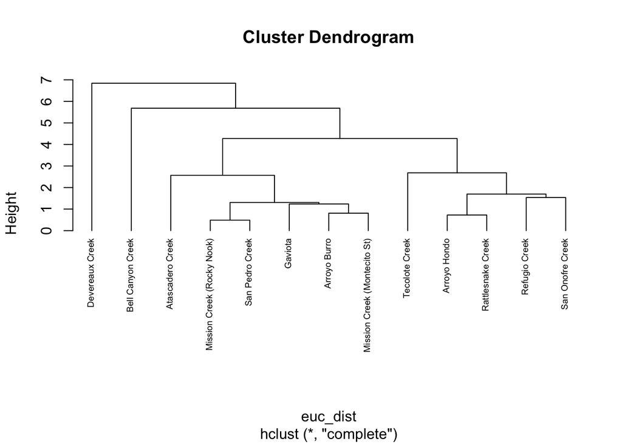

```r
### calculate the euc dists
euc_dist <- dist(stream_chem_scale, method = 'euclidean')
### use stats::hclust() for hierarchical clustering
stream_hc_complete <- hclust(euc_dist, method = 'complete')
### quick base plot check:
 plot(stream_hc_complete, cex = 0.6, hang = -1)
```

**Figure A.** A dendrogram showing Santa Barbara streams chemistry similarity by hierarchical clustering. The y-axis indicates how similar the stream chemistry is by water sample sites.

## Summary

Our cluster dendrogram can give us insights into the similarities between streams in Santa Barbara based on water samples.

- San Pedro Creek and Mission Creek (Rocky Nook) share the most similarities, on average
- Devereaux Creek is the most dissimilar of the streams